# Ford-GoBike-Data-Visualization Project

## Introduction

Ford-GoBike dataset includes information about individual rides made in a Bikesharing system

## Dataset Wrangling

```python
#Here all the required packages.
import seaborn as sns
import pandas as pd
import numpy as np
import matplotlib.pyplot as plt
%matplotlib inline
```

```python
df = pd.read_csv('201902-fordgobike-tripdata.csv')
```

```python
df.info()
```

```
<class 'pandas.core.frame.DataFrame'>
RangeIndex: 183412 entries, 0 to 183411
Data columns (total 16 columns):
 #   Column                   Non-Null Count   Dtype
---  ------                   --------------   -----
 0   duration_sec             183412 non-null  int64
 1   start_time               183412 non-null  object
 2   end_time                 183412 non-null  object
 3   start_station_id         183215 non-null  float64
 4   start_station_name       183215 non-null  object
 5   start_station_latitude   183412 non-null  float64
 6   start_station_longitude  183412 non-null  float64
 7   end_station_id           183215 non-null  float64
 8   end_station_name         183215 non-null  object
 9   end_station_latitude     183412 non-null  float64
 10  end_station_longitude    183412 non-null  float64
 11  bike_id                  183412 non-null  int64
 12  user_type                183412 non-null  object
 13  member_birth_year        175147 non-null  float64
 14  member_gender            175147 non-null  object
 15  bike_share_for_all_trip  183412 non-null  object
dtypes: float64(7), int64(2), object(7)
memory usage: 22.4+ MB
```

```python
'''
Create a new clean copy, it is  a good approach, since if the dataframe has beeen corupted at any step,
I could return to this step instead of excuting all from the 1st.
'''
clean_df = df.copy()
```

```python
# To see the overall form of our dataset
clean_df.head()
```

|  | duration_sec | start_time | end_time | start_station_id | start_station_name | start_station_latitude | start_station_longitude | end_station_id | end_station_name | end_station_latitude | end_station_longitude | bike_id | user_type | member_birth_year | member_gender | bike_share_for_all_trip |
| --- | --- | --- | --- | --- | --- | --- | --- | --- | --- | --- | --- | --- | --- | --- | --- | --- |
| 0 | 52185 | 2019-02-28 17:32:10.1450 | 2019-03-01 08:01:55.9750 | 21.0 | Montgomery St BART Station (Market St at 2nd St) | 37.789625 | -122.400811 | 13.0 | Commercial St at Montgomery St | 37.794231 | -122.402923 | 4902 | Customer | 1984.0 | Male | No |
| 1 | 42521 | 2019-02-28 18:53:21.7890 | 2019-03-01 06:42:03.0560 | 23.0 | The Embarcadero at Steuart St | 37.791464 | -122.391034 | 81.0 | Berry St at 4th St | 37.775880 | -122.393170 | 2535 | Customer | NaN | NaN | No |
| 2 | 61854 | 2019-02-28 12:13:13.2180 | 2019-03-01 05:24:08.1460 | 86.0 | Market St at Dolores St | 37.769305 | -122.426826 | 3.0 | Powell St BART Station (Market St at 4th St) | 37.786375 | -122.404904 | 5905 | Customer | 1972.0 | Male | No |
| 3 | 36490 | 2019-02-28 17:54:26.0100 | 2019-03-01 04:02:36.8420 | 375.0 | Grove St at Masonic Ave | 37.774836 | -122.446546 | 70.0 | Central Ave at Fell St | 37.773311 | -122.444293 | 6638 | Subscriber | 1989.0 | Other | No |
| 4 | 1585 | 2019-02-28 23:54:18.5490 | 2019-03-01 00:20:44.0740 | 7.0 | Frank H Ogawa Plaza | 37.804562 | -122.271738 | 222.0 | 10th Ave at E 15th St | 37.792714 | -122.248780 | 4898 | Subscriber | 1974.0 | Male | Yes |

### Removing Nan Values from dataframe

```python
# Drop all rows which includes None values.
clean_df.dropna(inplace=True)
```

### Fixing the datatype

```python
# Fixing start_time, end_time from object to datetime64
clean_df.start_time = pd.to_datetime(clean_df.start_time)
clean_df.end_time = pd.to_datetime(clean_df.end_time)

#converting bike_id into string, it is not necessary to make it int. There is no math operation will be done here
clean_df.bike_id = clean_df.bike_id.astype('object')

# converting member_birth_year from float to int
clean_df.member_birth_year = clean_df.member_birth_year.astype('int')
```

```python
clean_df.info()
```

```
<class 'pandas.core.frame.DataFrame'>
Int64Index: 174952 entries, 0 to 183411
Data columns (total 16 columns):
 #   Column                   Non-Null Count   Dtype
---  ------                   --------------   -----
 0   duration_sec             174952 non-null  int64
 1   start_time               174952 non-null  datetime64[ns]
 2   end_time                 174952 non-null  datetime64[ns]
 3   start_station_id         174952 non-null  float64
 4   start_station_name       174952 non-null  object
 5   start_station_latitude   174952 non-null  float64
 6   start_station_longitude  174952 non-null  float64
 7   end_station_id           174952 non-null  float64
 8   end_station_name         174952 non-null  object
 9   end_station_latitude     174952 non-null  float64
 10  end_station_longitude    174952 non-null  float64
 11  bike_id                  174952 non-null  object
 12  user_type                174952 non-null  object
 13  member_birth_year        174952 non-null  int32
 14  member_gender            174952 non-null  object
 15  bike_share_for_all_trip  174952 non-null  object
dtypes: datetime64[ns](2), float64(6), int32(1), int64(1), object(6)
memory usage: 22.0+ MB
```

### Adding Month, day, weekday, time, date, hour, member_age Columns

```python
# Add necessary columns for answering questions.
clean_df['date'] = pd.DatetimeIndex(clean_df['start_time']).date
clean_df.date = clean_df.date.astype('datetime64')

clean_df['day'] = pd.DatetimeIndex(clean_df['start_time']).day
clean_df['week_day'] = clean_df['date'].dt.day_name()
clean_df['time'] = pd.DatetimeIndex(clean_df['start_time']).time
clean_df.time = clean_df.time.astype('str')


clean_df['hour'] = pd.DatetimeIndex(clean_df['start_time']).hour
clean_df.hour = clean_df.hour.astype('int')

clean_df['member_age'] = 2019-clean_df['member_birth_year']
```

```python
# Here to test the added columns
clean_df.info()
```

```
<class 'pandas.core.frame.DataFrame'>
Int64Index: 174952 entries, 0 to 183411
Data columns (total 22 columns):
 #   Column                   Non-Null Count   Dtype
---  ------                   --------------   -----
 0   duration_sec             174952 non-null  int64
 1   start_time               174952 non-null  datetime64[ns]
 2   end_time                 174952 non-null  datetime64[ns]
 3   start_station_id         174952 non-null  float64
 4   start_station_name       174952 non-null  object
 5   start_station_latitude   174952 non-null  float64
 6   start_station_longitude  174952 non-null  float64
 7   end_station_id           174952 non-null  float64
 8   end_station_name         174952 non-null  object
 9   end_station_latitude     174952 non-null  float64
 10  end_station_longitude    174952 non-null  float64
 11  bike_id                  174952 non-null  object
 12  user_type                174952 non-null  object
 13  member_birth_year        174952 non-null  int32
 14  member_gender            174952 non-null  object
 15  bike_share_for_all_trip  174952 non-null  object
 16  date                     174952 non-null  datetime64[ns]
 17  day                      174952 non-null  int64
 18  week_day                 174952 non-null  object
 19  time                     174952 non-null  object
 20  hour                     174952 non-null  int32
 21  member_age               174952 non-null  int32
dtypes: datetime64[ns](3), float64(6), int32(3), int64(2), object(8)
memory usage: 28.7+ MB
```

### Fixing the time Column Items

```python
# Fxing the data in this column to include just the time value like this hh:mm:ss
clean_df['time'] = clean_df['time'].apply(lambda x: x[:-7] if '.' in x else x)
```

### Removing not required Columns

```python
#Remove all columns that are not necessary for our questions and store this into our new exploration dataframe
elpor_df = clean_df.drop(columns=['end_station_id', 'start_station_id', 'start_station_latitude', 'start_station_longitude', 'end_station_latitude','end_station_longitude'])
```

```python
#Test the remove operation
elpor_df.info()
```

```
<class 'pandas.core.frame.DataFrame'>
Int64Index: 174952 entries, 0 to 183411
Data columns (total 16 columns):
 #   Column                   Non-Null Count   Dtype
---  ------                   --------------   -----
 0   duration_sec             174952 non-null  int64
 1   start_time               174952 non-null  datetime64[ns]
 2   end_time                 174952 non-null  datetime64[ns]
 3   start_station_name       174952 non-null  object
 4   end_station_name         174952 non-null  object
 5   bike_id                  174952 non-null  object
 6   user_type                174952 non-null  object
 7   member_birth_year        174952 non-null  int32
 8   member_gender            174952 non-null  object
 9   bike_share_for_all_trip  174952 non-null  object
 10  date                     174952 non-null  datetime64[ns]
 11  day                      174952 non-null  int64
 12  week_day                 174952 non-null  object
 13  time                     174952 non-null  object
 14  hour                     174952 non-null  int32
 15  member_age               174952 non-null  int32
dtypes: datetime64[ns](3), int32(3), int64(2), object(8)
memory usage: 20.7+ MB
```

## Exploration

```python
elpor_df.head()
```

|  | duration_sec | start_time | end_time | start_station_name | end_station_name | bike_id | user_type | member_birth_year | member_gender | bike_share_for_all_trip | date | day | week_day | time | hour | member_age |
| --- | --- | --- | --- | --- | --- | --- | --- | --- | --- | --- | --- | --- | --- | --- | --- | --- |
| 0 | 52185 | 2019-02-28 17:32:10.145 | 2019-03-01 08:01:55.975 | Montgomery St BART Station (Market St at 2nd St) | Commercial St at Montgomery St | 4902 | Customer | 1984 | Male | No | 2019-02-28 | 28 | Thursday | 17:32:10 | 17 | 35 |
| 2 | 61854 | 2019-02-28 12:13:13.218 | 2019-03-01 05:24:08.146 | Market St at Dolores St | Powell St BART Station (Market St at 4th St) | 5905 | Customer | 1972 | Male | No | 2019-02-28 | 28 | Thursday | 12:13:13 | 12 | 47 |
| 3 | 36490 | 2019-02-28 17:54:26.010 | 2019-03-01 04:02:36.842 | Grove St at Masonic Ave | Central Ave at Fell St | 6638 | Subscriber | 1989 | Other | No | 2019-02-28 | 28 | Thursday | 17:54:26 | 17 | 30 |
| 4 | 1585 | 2019-02-28 23:54:18.549 | 2019-03-01 00:20:44.074 | Frank H Ogawa Plaza | 10th Ave at E 15th St | 4898 | Subscriber | 1974 | Male | Yes | 2019-02-28 | 28 | Thursday | 23:54:18 | 23 | 45 |
| 5 | 1793 | 2019-02-28 23:49:58.632 | 2019-03-01 00:19:51.760 | 4th St at Mission Bay Blvd S | Broadway at Kearny | 5200 | Subscriber | 1959 | Male | No | 2019-02-28 | 28 | Thursday | 23:49:58 | 23 | 60 |

### Univariate visualization

#### What is the Distribution of Age?

The distribution of age is right-skewed. Most of people who use the bikeshare service are from 20 to 45.

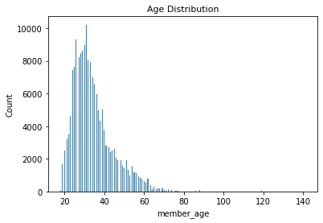

```python
# To know the distributin, the histograme is useful in this case
sns.histplot(data=elpor_df, x="member_age");
plt.title("Age Distribution", fontsize=11);
```

#### What is the Distribution of rides per Weekday?

From below Figure,

- We can say that Thrusday has the most rideshares.
- Also, We notice, that the number of shares decreases on week ends.

```python
week_day_count = elpor_df.week_day.value_counts()
```

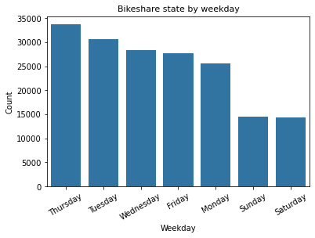

```python
# To know the number of rides on each week day

color = sns.color_palette()[0]

sns.barplot(x=week_day_count.index.values, y=week_day_count.values,color=color)
plt.title("Bikeshare state by weekday", fontsize=11);
plt.xticks(rotation=30);
plt.ylabel('Count');
plt.xlabel('Weekday');
```

#### What is the Percentage for each Gender in Bikesharing System?

From below figure,

- We see that the male is the most gender percentage.
- It has percentage of 74.6%.

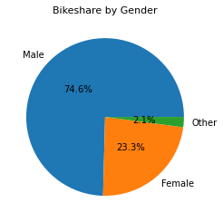

```python
# Since all genders we have is 3 cateogries, so we can use the pie chart in this case.
data = elpor_df.member_gender.value_counts()
plt.pie(x=data.values, autopct="%.1f%%", labels=data.index.values, pctdistance=0.5)
plt.title("Bikeshare by Gender", fontsize=11);
```

#### What is the Percentage for each User Type in Bikesharing System?

From below,

- we can say that the user type subscriber has the most share with us.

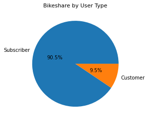

```python
## Since all user types we have is 2, so we can use the pie chart in this case

usertype_data = elpor_df.user_type.value_counts()
plt.pie(x=usertype_data.values, autopct="%.1f%%", labels=usertype_data.index.values, pctdistance=0.5)
plt.title("Bikeshare by User Type", fontsize=11);
```

#### What the Name of the most Station has Bikesharing System?

From below figure, we see the names of the most important station names

```python
# To get the most common 10 station names in the dataframe
station_count = elpor_df.start_station_name.value_counts()[:10]
```

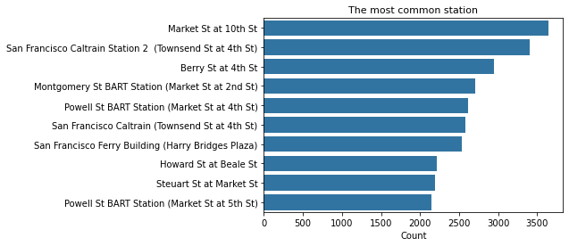

```python
# To use the basic colorr for all bars, it is not good to use a unique color for each bar.
color = sns.color_palette()[0]
sns.barplot(x=station_count.values, y=station_count.index.values, color=color)
plt.title("The most common station", fontsize=11);
plt.xlabel('Count');
```

#### What is the Share State per each hour in day?

> Here, we notice the followings:

> The number of shares has largest between 8 to 10 and 4pm to 7pm.

> The sharing bike has contant usage between 7 am to 8 pm.

```python
# To get the hours with thier repetions in our dataframe
hour_count = elpor_df.hour.value_counts()
```

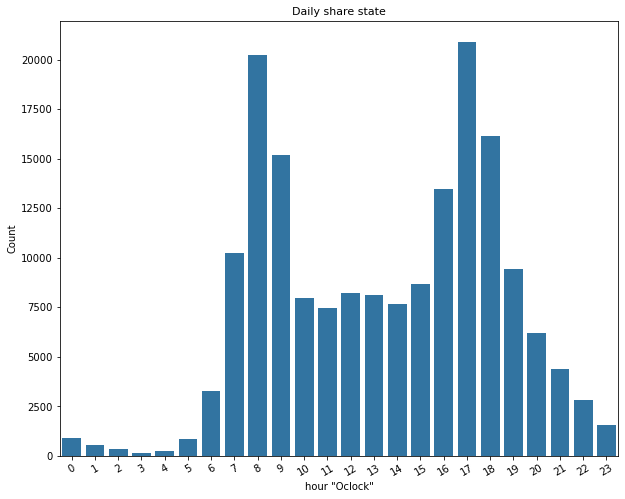

```python
# Since we have 24 hour, so we should take care of figure size.
color = sns.color_palette()[0]
plt.figure(figsize=(10, 8))
sns.barplot(y=hour_count.values, x=hour_count.index.values, color=color)
plt.xticks(rotation=30);
plt.title("Daily share state", fontsize=11);
plt.ylabel('Count');
plt.xlabel('hour "Oclock"');
```

### Bivariate Visualization

#### Which Generation use Bikeshare longer?

Here in the below figure, we notice that,

- People who born after 1960, or less than 60 who share bikes more than others.

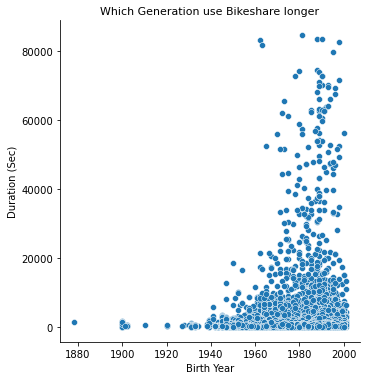

```python
# To discover the replation between birth year and the duration with seconds, I used scatter plot, since bothe are numerical
sns.relplot(data = elpor_df, x='member_birth_year', y='duration_sec' )
plt.title("Which Generation use Bikeshare longer", fontsize=11);
plt.ylabel('Duration (Sec)');
plt.xlabel('Birth Year');
```

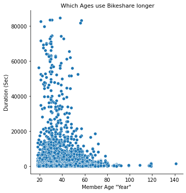

```python
sns.relplot(data = elpor_df, x='member_age', y='duration_sec' )
plt.title(" Which Ages use Bikeshare longer", fontsize=11);
plt.ylabel('Duration (Sec)');
plt.xlabel('Member Age "Year"');
```

#### Which Member Gender use Bikesharing longer?

From below figure, we notice that

- The other gender use the bike longer than male or felmale. The other use the bike on average 16 Minutes, males use the bike on average 11.6 Minutes, but females use it 13.33 Minutes.

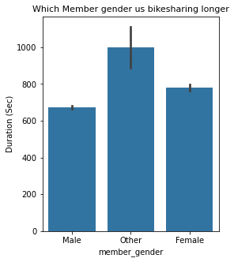

```python
# To discover on average duration which gender use the bike longer duaration.
color = sns.color_palette()[0]
plt.figure(figsize=(4, 5))

sns.barplot(data = elpor_df, y='duration_sec', x='member_gender', color=color)
plt.title("Which Member gender us bikesharing longer", fontsize=11);
plt.ylabel('Duration (Sec)');
```

#### Which User Type share Bikes longer?

From below figure, we notice that,

- The Customer user type use the bike longer than male or Subscriber.

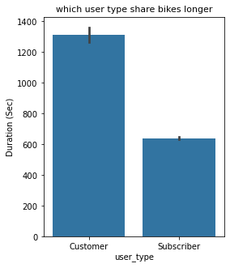

```python
# Here the bar plot is used, because it a relation between continous and categrical variable
color = sns.color_palette()[0]
plt.figure(figsize=(4, 5))

sns.barplot(data = elpor_df, y='duration_sec', x='user_type', color=color)
plt.title("which user type share bikes longer", fontsize=11);
plt.ylabel('Duration (Sec)');
```

#### How many seconds used per each ride on each weekday?

From below figure, we notice the following:

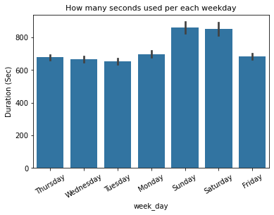

```python
# Here the bar plot is used, because it a relation between continous and categrical variable

color = sns.color_palette()[0]
sns.barplot(data = elpor_df, y='duration_sec', x='week_day', color=color)
plt.title("How many seconds used per each weekday", fontsize=11);
plt.ylabel('Duration (Sec)');
plt.xticks(rotation=30);
```

#### How many seconds used per each hour on average?

From the below graph, we notice the follwoing:

- The longest average duration is between 1 am to 4 am is 25 Minutes,
- All trips which on average about 10 minutes or 600 seconds will be between 4 am to 11 pm

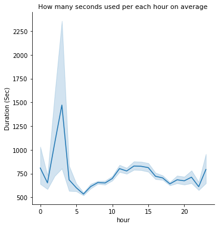

```python
sns.relplot(data = elpor_df, y='duration_sec', x='hour', kind='line')
plt.title("How many seconds used per each hour on average", fontsize=11);
plt.ylabel('Duration (Sec)');
```

### Mulitivariate Visualization

#### What the Trends of each Gender Type in the Relation between Duration_sec and Hour?

From below Figure we become sure from the following:

- The number of male who use bikeshare is more than females, and females number is more than others.
- Although the number of males who use Bikeshare longer than 16 Minutes are more than the number of otheers and females. But when we compare average of durations used by male compaered to average duratons by female and others. We found that the average used by other is the highest then females and then males.

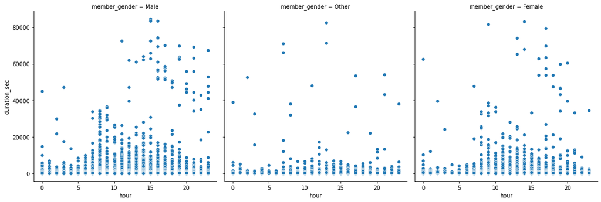

```python
sns.relplot(data = elpor_df, y='duration_sec', x='hour', col='member_gender')
```

#### What the Trends of each User Type in the Relation between Duration_sec and Hour?

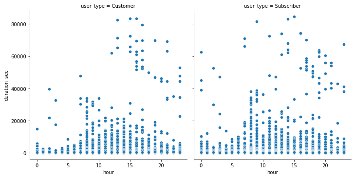

```python
sns.relplot(data = elpor_df, y='duration_sec', x='hour', col='user_type');
```

#### What is the Share Duration for each Gender?

From this lin chart:

- The average duration spend by others is more than the duration spend by Female,
- The duration spend by Females is longer than duration by males.

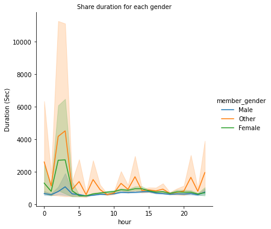

```python
sns.relplot(data = elpor_df, y='duration_sec', x='hour', kind='line', hue='member_gender')
plt.title( 'Share duration for each gender' , size = 10 )
plt.ylabel('Duration (Sec)');
```

#### What is the Share Count per Day considering Member_gender?

```python
bikes_per_day = elpor_df.groupby(['week_day','member_gender'])['bike_id'].count()
bikes_per_day = bikes_per_day.reset_index()
```

From below line chart, we can say that:

- Male number who use the Bikesharing system is more than the Female, and Female is more than others.
- Male and Female Number decreases in week ends week days Saturday and Sunday while others use the Bikeshare all day with constant ratio.

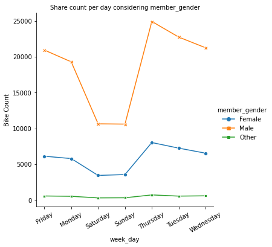

```python
sns.relplot(data = bikes_per_day, y='bike_id', x='week_day', hue='member_gender', style='member_gender', kind='line', markers=True, dashes=False)
plt.title( 'Share count per day considering member_gender' , size = 10 );
plt.ylabel('Bike Count');
plt.xticks(rotation=30);
```

#### What is the Share Count per Day considering User_type?

From the below line chart:

- The user type subscriber use the Bikesharing system all days with with high rate except the weekends. Their share decreases on these days.
- For Customer user type, they use the Bikeshare system with constatnt rate.

```python
bike_per_day = elpor_df.groupby(['week_day','user_type'])['bike_id'].count()
bike_per_day = bike_per_day.reset_index()
bike_per_day
```

|  | week_day | user_type | bike_id |
| --- | --- | --- | --- |
| 0 | Friday | Customer | 2541 |
| 1 | Friday | Subscriber | 25122 |
| 2 | Monday | Customer | 2309 |
| 3 | Monday | Subscriber | 23332 |
| 4 | Saturday | Customer | 2171 |
| 5 | Saturday | Subscriber | 12243 |
| 6 | Sunday | Customer | 2299 |
| 7 | Sunday | Subscriber | 12213 |
| 8 | Thursday | Customer | 2868 |
| 9 | Thursday | Subscriber | 30844 |
| 10 | Tuesday | Customer | 2268 |
| 11 | Tuesday | Subscriber | 28316 |
| 12 | Wednesday | Customer | 2110 |
| 13 | Wednesday | Subscriber | 26316 |

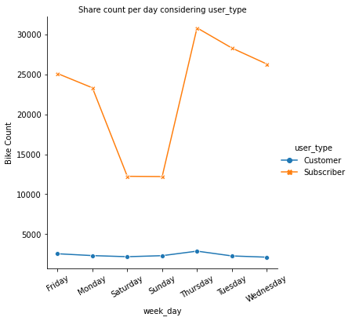

```python
sns.relplot(data = bike_per_day, y='bike_id', x='week_day', hue='user_type', style='user_type', kind='line', markers=True, dashes=False)
plt.title( 'Share count per day considering user_type' , size = 10 )
plt.ylabel('Bike Count');
plt.xticks(rotation=30);
```

#### What is Bikeshare Count per Day considering User_Type?

- This emphasize that subscriber use bikesharing on weekends which is 2,3,9,10,16,17,23,24, with lowest rate.
- But also, it has a strange behaviour on the 13th of February, since it is not a week end, but the bikeshare number has been decreased in both cutomer types on that day.

```python
bike_per_d = elpor_df.groupby(['day','user_type'])['bike_id'].count()
bike_per_d = bike_per_d.reset_index()
```

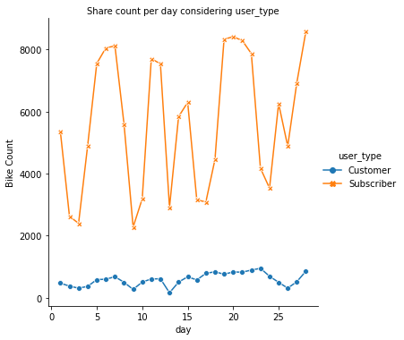

```python
sns.relplot(data = bike_per_d, y='bike_id', x='day', hue='user_type', style='user_type', kind='line', markers=True, dashes=False)
plt.title( 'Share count per day considering user_type' , size = 10 )
plt.ylabel('Bike Count');
```